# pseudobulk analysis report

SS

2024-01-24

## Checking that the input counts don’t have global sequencing-depth effect

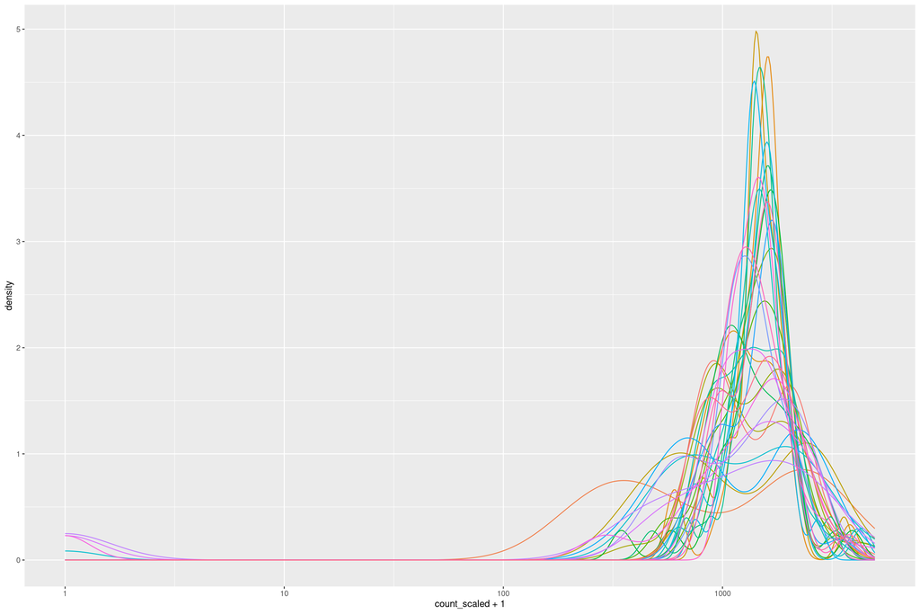

## Calculate PCA of pseudobulk

## Scree plot

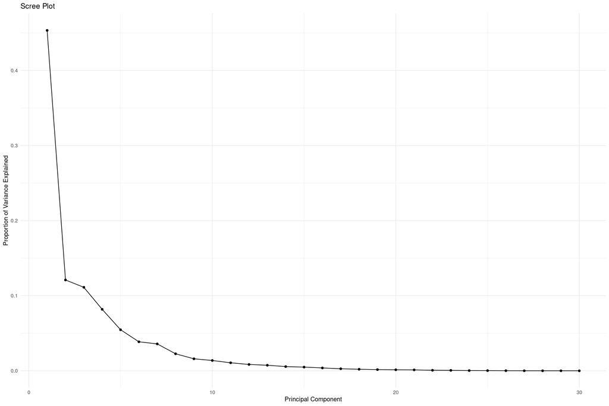

## Principal Component Associations with Biological Variables

Here we see which variable is associated with which principal component. We hope the biological variable are associated with the top principal components.

The distance of the points from the origin (where PC1 and PC2 both equal zero) indicates how much variance each sample has relative to the principal components. Samples that are further out along PC1 or PC2 axes have higher variance for those components.

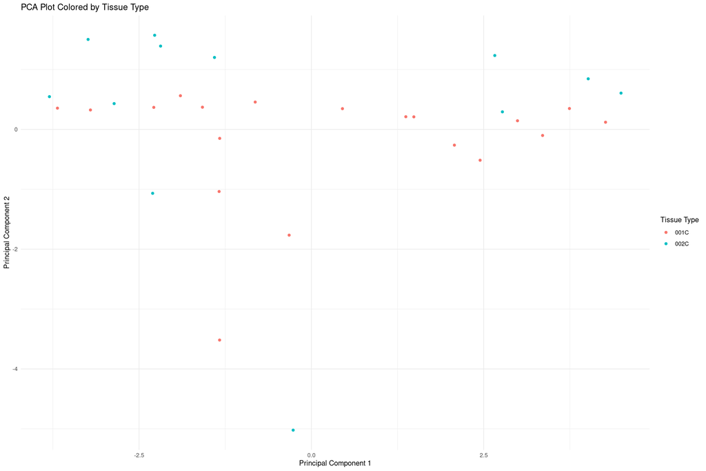

## Cell type clustering

- The separation or clustering of points with the same color might suggest that similar cell types have similar gene expression profiles, while different colors that group together could indicate distinct profiles between cell types.
- The distance between the points on the plot reflects the similarity or dissimilarity in their gene expression data, as captured by the PCA.

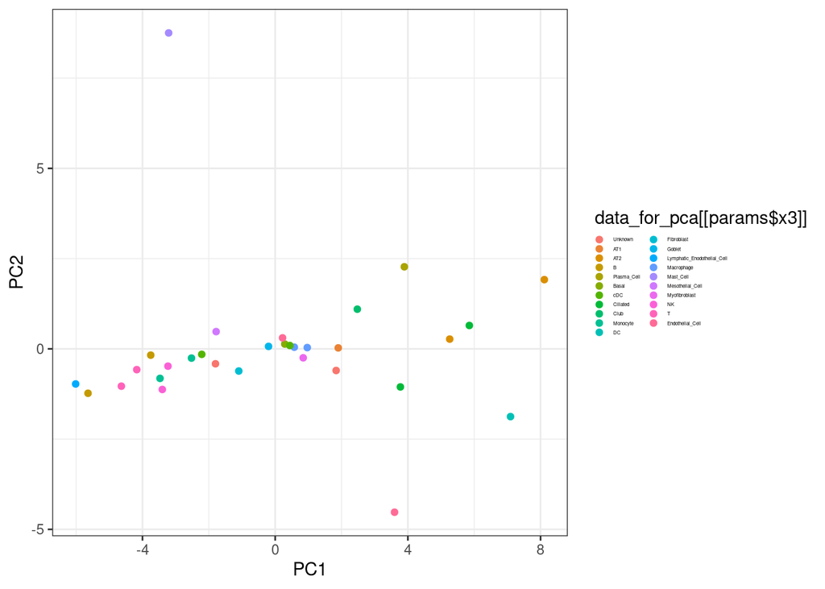